# Take Home Exam - Intro to Predictive Modelling

Akhilesh Reddy Narapareddy ( UTEID : an27467)

August 1, 2018

### Chapter 2 : Problem #10

#### This exercise involves the Boston housing data set.

#### To begin, load in the Boston data set. The Boston data set is

#### part of the MASS library in R.Now the data set is contained in the object Boston.

#### a.How many rows are in this data set? How many columns? What do the rows and columns represent?

- No of rows : 506
- No of columns : 14

#### (b) Make some pairwise scatterplots of the predictors (columns) in

#### this data set. Describe your findings.

** Findings: **  
* rm(average number of rooms per dwelling) and lstat(lower status of the population (percent)) has a strong correlation with medv and crim might have a non linear relationship with medv

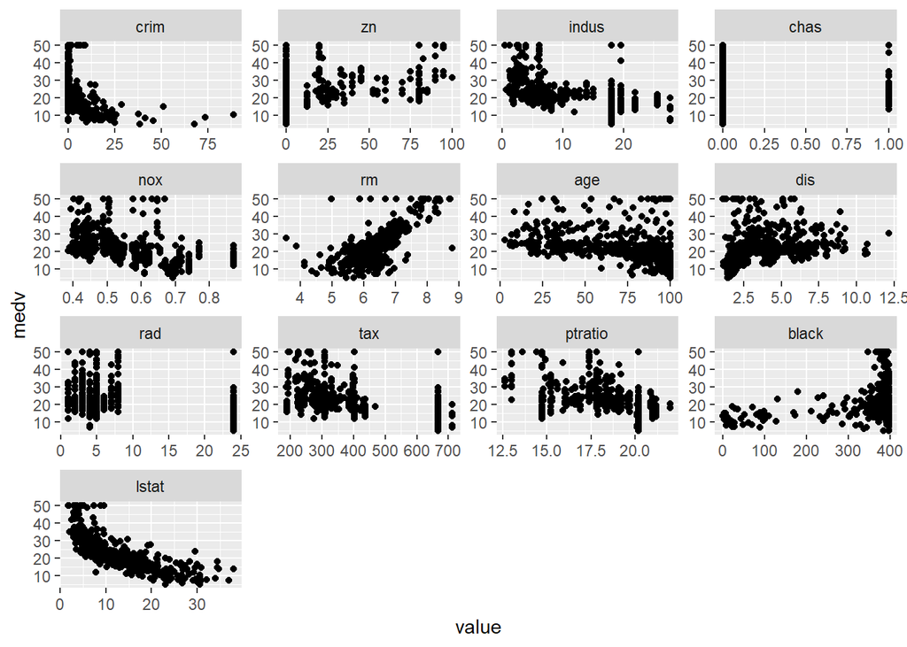

```r
library(MASS)
require(ggplot2)
require(lattice)
library(reshape2)


boston = Boston
## Rows represent the various suburbs in Boston and the columns represent
## the various characteristics of each suburb


mtmelt <- melt(boston, id = "medv")
ggplot(mtmelt, aes(x = value, y = medv)) +
  facet_wrap(~variable, scales = "free") +
  geom_point()
```

#### (c) Are any of the predictors associated with per capita crime rate? If so, explain the relationship.

#### Answer:

- Access to highways and high tax rate have a high positive correlation with per capita crime rate
- Also, it is worth noting that the black population has a negative correlation with per capita crime rate

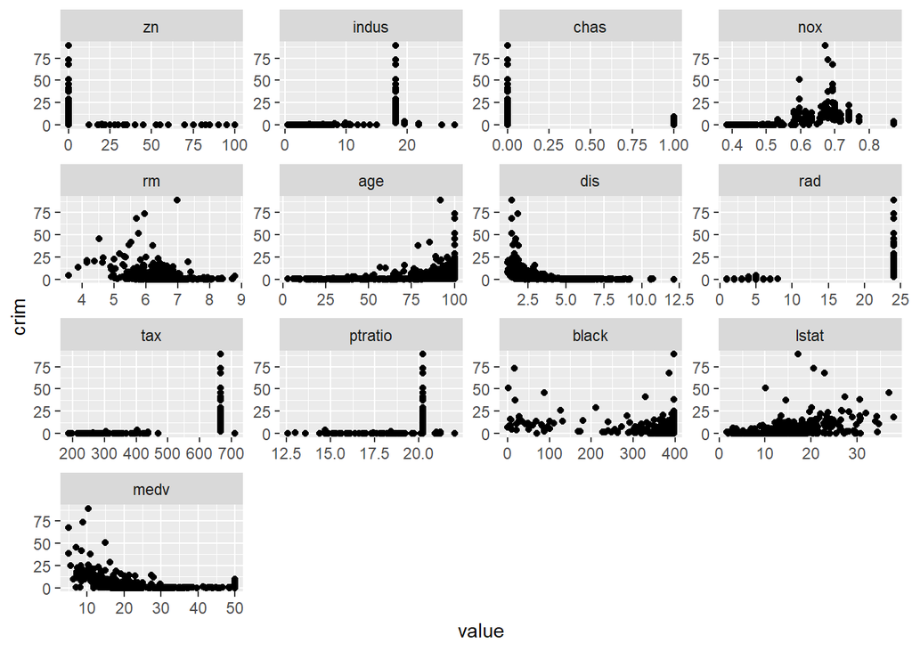

```r
mtmelt <- melt(boston, id = "crim")
ggplot(mtmelt, aes(x = value, y = crim)) +
  facet_wrap(~variable, scales = "free") +
  geom_point()
```

```r
head(mtmelt)
```

```
##      crim variable value
## 1 0.00632       zn    18
## 2 0.02731       zn     0
## 3 0.02729       zn     0
## 4 0.03237       zn     0
## 5 0.06905       zn     0
## 6 0.02985       zn     0
```

```r
boston_treated = na.omit(boston)
sum(is.na(boston_treated$crim))
```

```
## [1] 0
```

```r
k <- cor(boston_treated)
k1 <- k[1,2:14] ## Correlation of per capita crime rate with other variables
k1
```

```
##          zn       indus        chas         nox          rm         age
## -0.20046922  0.40658341 -0.05589158  0.42097171 -0.21924670  0.35273425
##         dis         rad         tax     ptratio       black       lstat
## -0.37967009  0.62550515  0.58276431  0.28994558 -0.38506394  0.45562148
##        medv
## -0.38830461
```

#### (d) Do any of the suburbs of Boston appear to have particularly high crime rates? Tax rates? Pupil-teacher ratios? Comment on the range of each predictor

#### Answer:

- ptratio has a small range where as tax has a very vast range of values
- Multiple suburbs have crim outliers

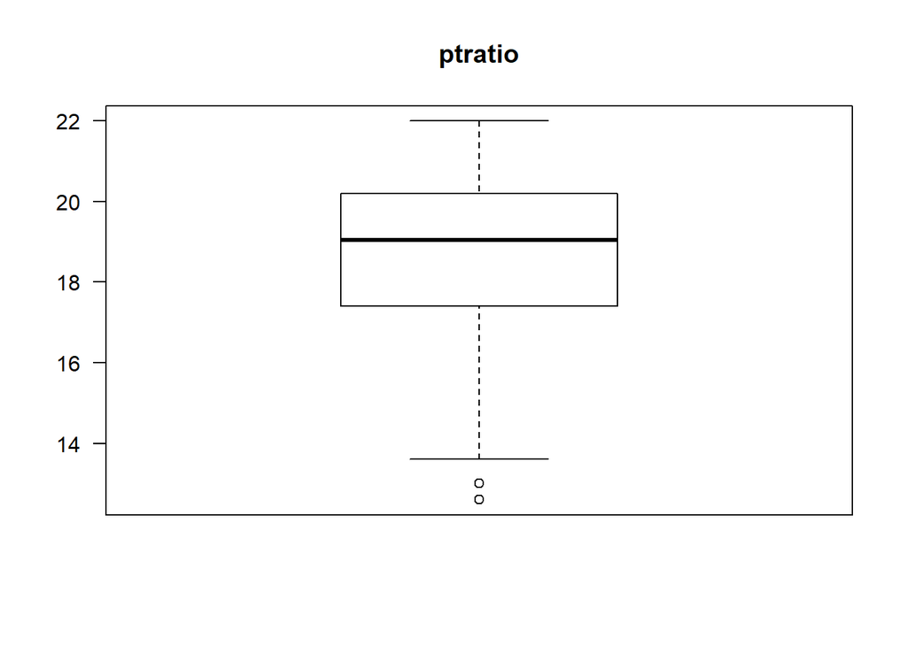

```r
boxplot(boston_treated$ptratio, las =2,main="ptratio")
```

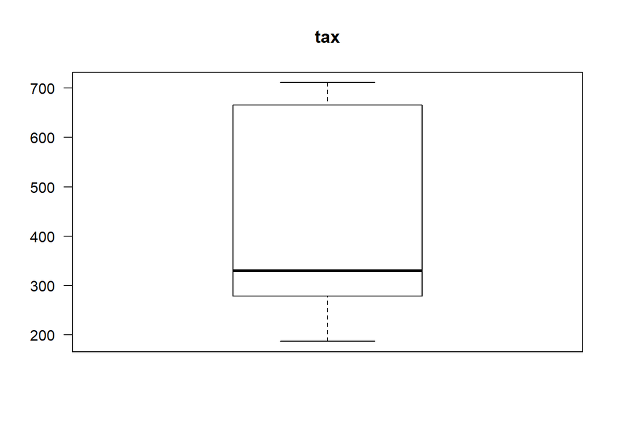

```r
## ptratio
## Has 2 outliers in the lower end of the data

boxplot(Boston$tax, las =2,main="tax")
```

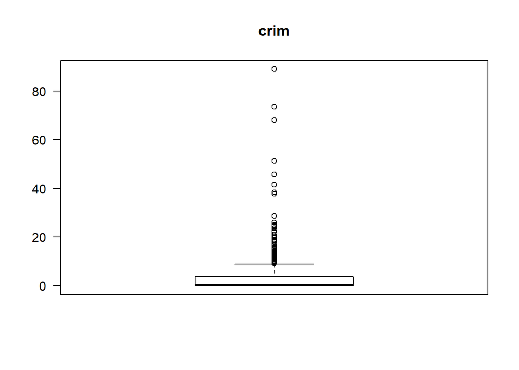

```r
## There are no outliers in the tax rates data

boxplot(Boston$crim, las =2,main="crim")
```

```r
## A couple of cities on the top have high crime rates
```

#### (e) How many of the suburbs in this data set bound the Charles river?

#### Answer:

- 35 suburbs

```r
on_river <- sum(Boston$chas == 1, na.rm=TRUE)
on_river
```

```
## [1] 35
```

#### (f) What is the median pupil-teacher ratio among the towns in this data set?

#### Answer:

- 19.05

```r
summary(Boston$ptratio)
```

```
##    Min. 1st Qu.  Median    Mean 3rd Qu.    Max.
##   12.60   17.40   19.05   18.46   20.20   22.00
```

#### (g) Which suburb of Boston has lowest median value of owneroccupied homes? What are the values of the other predictors for that suburb, and how do those values compare to the overall ranges for those predictors? Comment on your findings.

```r
ind <- which.min(Boston$medv)
Boston[399,]
```

```
##        crim zn indus chas   nox    rm age    dis rad tax ptratio black
## 399 38.3518  0  18.1    0 0.693 5.453 100 1.4896  24 666    20.2 396.9
##     lstat medv
## 399 30.59    5
```

#### (h) In this data set, how many of the suburbs average more than seven rooms per dwelling? More than eight rooms per dwelling? Comment on the suburbs that average more than eight rooms per dwelling.

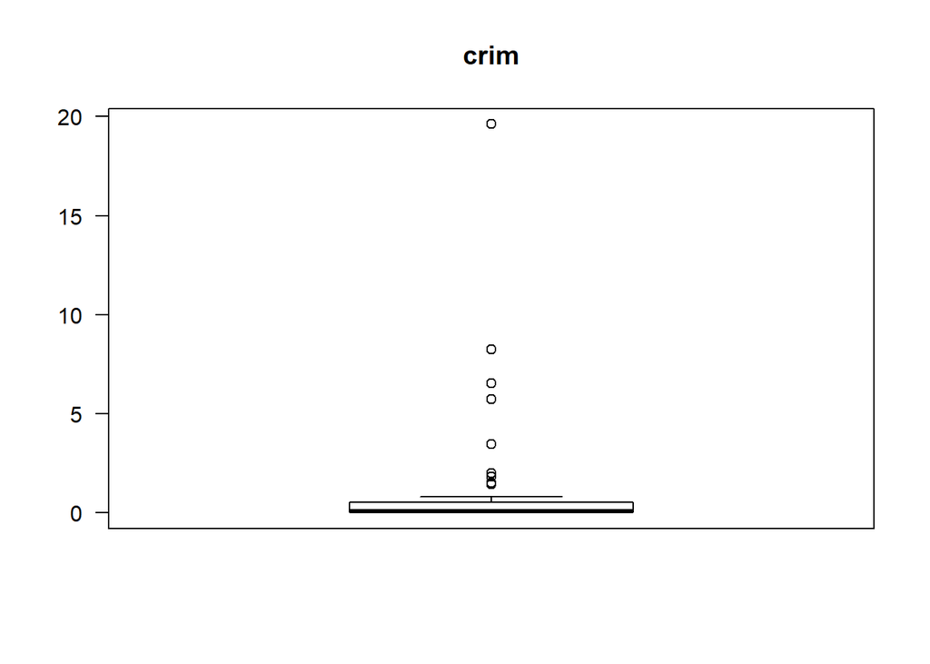

```r
gt_7 <- sum(Boston$rm > 7)
gt_8 <- sum(Boston$rm > 8)
suburbs_rm_7 = subset(boston_treated,rm > 7 )
boxplot(suburbs_rm_7$crim, las =2,main = "crim")
```

### Chapter 3 #15

### This problem involves the Boston data set, which we saw in the lab for this chapter. We will now try to predict per capita crime rate using the other variables in this data set. In other words, per capita crime rate is the response, and the other variables are the predictors.

#### a. For each predictor, fit a simple linear regression model to predict the response. Describe your results. In which of the models is there a statistically significant association between the predictor and the response? Create some plots to back up your assertions

#### Answer:

- Crime rate is positively influenced by rad and tax variables
- Fitting the linear regression model for each predictor  
  **Results**:
- rad and tax predictors explain the maximum variability in the response variable with adjusted R^2 closer to 35%
- All the predictors are statistically significant in explaining the response variable based on their p-value which is less than 0.05 except for chas

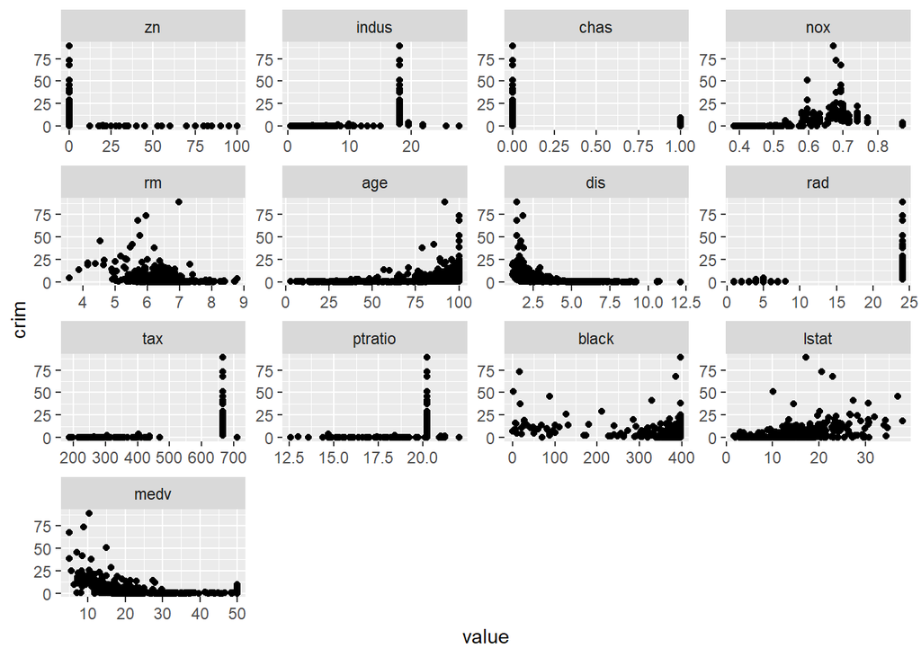

```r
# Checking the correlation between the response variable and the predictors
# Plotting pairwise scatterplots to check the correlation
boston_treated = na.omit(Boston)
mtmelt <- melt(boston_treated, id = "crim")
ggplot(mtmelt, aes(x = value, y = crim)) +
  facet_wrap(~variable, scales = "free") +
  geom_point()
```

```r
# Correlation
corr1 = cor(boston_treated)
corr1[1,]
```

```
##        crim          zn       indus        chas         nox          rm
##  1.00000000 -0.20046922  0.40658341 -0.05589158  0.42097171 -0.21924670
##         age         dis         rad         tax     ptratio       black
##  0.35273425 -0.37967009  0.62550515  0.58276431  0.28994558 -0.38506394
##       lstat        medv
##  0.45562148 -0.38830461
```

```r
predIdx <- c(2:14);

k = lapply(predIdx, function(x) lm(Boston$crim ~ Boston[, x],na.action = na.omit))
var_names <- names(Boston[,2:14])
names(k) = var_names
p_value = list()
r_squared = list()
coeff = list()
for (i in 1:13){
  p_value[i] = summary(k[[i]])$coefficients[2,4]
  r_squared[i]= summary(k[[i]])$r.squared[1]
  coeff[i] = summary(k[[i]])$coefficients[2,1]
}
results = cbind(var_names,p_value,r_squared)
single_pred_coeff = cbind(var_names,coeff)

library (plyr)
summary(k[[1]])
```

```
##
## Call:
## lm(formula = Boston$crim ~ Boston[, x], na.action = na.omit)
##
## Residuals:
##    Min     1Q Median     3Q    Max
## -4.429 -4.222 -2.620  1.250 84.523
##
## Coefficients:
##             Estimate Std. Error t value Pr(>|t|)
## (Intercept)  4.45369    0.41722  10.675  < 2e-16 ***
## Boston[, x] -0.07393    0.01609  -4.594 5.51e-06 ***
## ---
## Signif. codes:  0 '***' 0.001 '**' 0.01 '*' 0.05 '.' 0.1 ' ' 1
##
## Residual standard error: 8.435 on 504 degrees of freedom
## Multiple R-squared:  0.04019,    Adjusted R-squared:  0.03828
## F-statistic:  21.1 on 1 and 504 DF,  p-value: 5.506e-06
```

```r
# Creating a column with all the regression coefficients
l = lapply(1:13, function(x) k[[x]]$coefficients[2])
names(l) = names(k)
sim_coeff <- ldply (l, data.frame)
sim_coeff
```

```
##        .id      X..i..
## 1       zn -0.07393498
## 2    indus  0.50977633
## 3     chas -1.89277655
## 4      nox 31.24853120
## 5       rm -2.68405122
## 6      age  0.10778623
## 7      dis -1.55090168
## 8      rad  0.61791093
## 9      tax  0.02974225
## 10 ptratio  1.15198279
## 11   black -0.03627964
## 12   lstat  0.54880478
## 13    medv -0.36315992
```

```r
library(data.table)
setnames(sim_coeff, old=c(".id","X..i.."), new=c("Predictor", "sim_coeff"))
```

#### b.Fit a multiple regression model to predict the response using all of the predictors. Describe your results. For which predictors can we reject the null hypothesis H0 : Î²j = 0?

**Results**: * All the predictors combined can successfully explain close to 45% of the variation in the response variable  
* rad,dis,black,medv,zn have relatively high t-value suggesting that they have a good influence on the response variable  
* Null hypothesis can be rejected for rad,dis,black,medv,zn

```r
# Fitting a multiple linear regression model
set.seed(4)
lm.fit = lm(Boston$crim~.,Boston)
summary(lm.fit)
```

```
##
## Call:
## lm(formula = Boston$crim ~ ., data = Boston)
##
## Residuals:
##    Min     1Q Median     3Q    Max
## -9.924 -2.120 -0.353  1.019 75.051
##
## Coefficients:
##               Estimate Std. Error t value Pr(>|t|)
## (Intercept)  17.033228   7.234903   2.354 0.018949 *
## zn            0.044855   0.018734   2.394 0.017025 *
## indus        -0.063855   0.083407  -0.766 0.444294
## chas         -0.749134   1.180147  -0.635 0.525867
## nox         -10.313535   5.275536  -1.955 0.051152 .
## rm            0.430131   0.612830   0.702 0.483089
## age           0.001452   0.017925   0.081 0.935488
## dis          -0.987176   0.281817  -3.503 0.000502 ***
## rad           0.588209   0.088049   6.680 6.46e-11 ***
## tax          -0.003780   0.005156  -0.733 0.463793
## ptratio      -0.271081   0.186450  -1.454 0.146611
## black        -0.007538   0.003673  -2.052 0.040702 *
## lstat         0.126211   0.075725   1.667 0.096208 .
## medv         -0.198887   0.060516  -3.287 0.001087 **
## ---
## Signif. codes:  0 '***' 0.001 '**' 0.01 '*' 0.05 '.' 0.1 ' ' 1
##
## Residual standard error: 6.439 on 492 degrees of freedom
## Multiple R-squared:  0.454,  Adjusted R-squared:  0.4396
## F-statistic: 31.47 on 13 and 492 DF,  p-value: < 2.2e-16
```

```r
library(data.table)
# coefficients
l2 = lm.fit$coefficients
mul_coeff <- ldply (l2, data.frame)
setnames(mul_coeff, old=c(".id","X..i.."), new=c("Predictor", "mul_coeff"))
```

#### How do your results from (a) compare to your results from (b)?Create a plot displaying the univariate regression coefficients from (a) on the x-axis, and the multiple regression coefficientsfrom (b) on the y-axis. That is, each predictor is displayed as a single point in the plot. Its coefficient in a simple linear regression model is shown on the x-axis, and its coefficient estimate in the multiple linear regression model is shown on the y-axis.

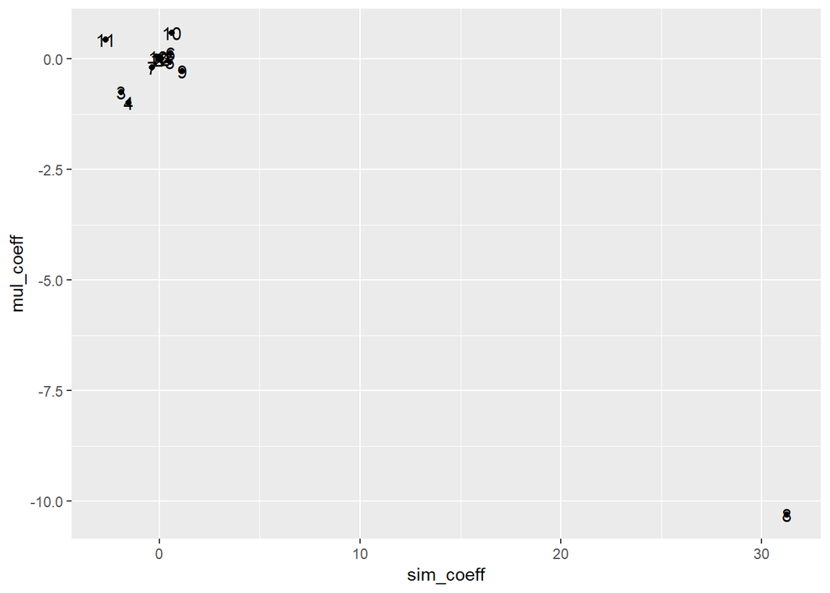

```r
# Inner join on sim_coeff and mul_coeff to get the data frame with both value in the same dataset
 i = merge(sim_coeff, mul_coeff, by = 'Predictor')

# Plotting a scatter plot
ggplot(i, aes(x=sim_coeff, y=mul_coeff)) +
  geom_point() +
  geom_text(label=rownames(i))
```

#### Is there evidence of non-linear association between any of the predictors and the response? To answer this question, for each predictor X, fit a model of the form

#### Findings:

- nox,rm,age,dis and medv have a non linear relationship with crim variable as adjusted R2 has increased by fitting a non-linear model

```r
predIdx <- c(2:14);

k = lapply(predIdx, function(x) lm(Boston$crim ~ Boston[, x]+I(Boston[, x]^2)+I(Boston[, x]^3)))
names(k) <- names(Boston[,2:14])
summary(k[[13]])
```

```
##
## Call:
## lm(formula = Boston$crim ~ Boston[, x] + I(Boston[, x]^2) + I(Boston[,
##     x]^3))
##
## Residuals:
##     Min      1Q  Median      3Q     Max
## -24.427  -1.976  -0.437   0.439  73.655
##
## Coefficients:
##                    Estimate Std. Error t value Pr(>|t|)
## (Intercept)      53.1655381  3.3563105  15.840  < 2e-16 ***
## Boston[, x]      -5.0948305  0.4338321 -11.744  < 2e-16 ***
## I(Boston[, x]^2)  0.1554965  0.0171904   9.046  < 2e-16 ***
## I(Boston[, x]^3) -0.0014901  0.0002038  -7.312 1.05e-12 ***
## ---
## Signif. codes:  0 '***' 0.001 '**' 0.01 '*' 0.05 '.' 0.1 ' ' 1
##
## Residual standard error: 6.569 on 502 degrees of freedom
## Multiple R-squared:  0.4202, Adjusted R-squared:  0.4167
## F-statistic: 121.3 on 3 and 502 DF,  p-value: < 2.2e-16
```

### Problem: Chapter 6 #9

### In this exercise, we will predict the number of applications received using the other variables in the College data set.

#### a.Split the data set into a training set and a test set.

```r
library(ISLR)
college_copy = College

library(caret)
set.seed(99)

train <- createDataPartition(y=college_copy$Apps,p=0.8,list=FALSE)
train_data_coll <- college_copy[train,]
train.matrix.coll <- model.matrix(~., data=data.frame(train_data_coll))[,-1]
test_data_coll <- college_copy[-train,]
test.matrix.coll <- model.matrix(~., data=data.frame(test_data_coll))[,-1]
```

#### b.Fit a linear model using least squares on the training set, and report the test error obtained

```r
# Fitting the linear model
set.seed(99)
lm.fit = lm(train_data_coll$Apps~.,train_data_coll)
summary(lm.fit)
```

```
##
## Call:
## lm(formula = train_data_coll$Apps ~ ., data = train_data_coll)
##
## Residuals:
##     Min      1Q  Median      3Q     Max
## -4692.4  -377.4    -4.6   298.6  7655.3
##
## Coefficients:
##               Estimate Std. Error t value Pr(>|t|)
## (Intercept) -9.602e+02  4.402e+02  -2.181 0.029552 *
## PrivateYes  -4.190e+02  1.503e+02  -2.789 0.005459 **
## Accept       1.607e+00  4.206e-02  38.203  < 2e-16 ***
## Enroll      -7.136e-01  2.153e-01  -3.314 0.000974 ***
## Top10perc    4.293e+01  6.199e+00   6.925 1.11e-11 ***
## Top25perc   -1.140e+01  4.955e+00  -2.301 0.021713 *
## F.Undergrad -8.026e-03  4.041e-02  -0.199 0.842636
## P.Undergrad  8.545e-02  3.467e-02   2.465 0.013985 *
## Outstate    -1.113e-01  2.083e-02  -5.342 1.31e-07 ***
## Room.Board   2.216e-01  5.364e-02   4.132 4.11e-05 ***
## Books        2.361e-01  2.512e-01   0.940 0.347685
## Personal     3.294e-02  6.586e-02   0.500 0.617149
## PhD         -6.542e+00  5.196e+00  -1.259 0.208490
## Terminal    -5.109e+00  5.645e+00  -0.905 0.365739
## S.F.Ratio    2.859e+01  1.455e+01   1.964 0.049957 *
## perc.alumni  6.658e+00  4.576e+00   1.455 0.146198
## Expend       9.279e-02  1.300e-02   7.138 2.72e-12 ***
## Grad.Rate    6.379e+00  3.154e+00   2.022 0.043582 *
## ---
## Signif. codes:  0 '***' 0.001 '**' 0.01 '*' 0.05 '.' 0.1 ' ' 1
##
## Residual standard error: 1021 on 606 degrees of freedom
## Multiple R-squared:  0.932,  Adjusted R-squared:  0.9301
## F-statistic: 488.8 on 17 and 606 DF,  p-value: < 2.2e-16
```

```r
t = predict(lm.fit, test_data_coll)
t1 = data.frame(t)

answer = cbind(test_data_coll[,"Apps"],t1)
names(answer) <- c("actual", "predicted")
lm.rmse = sqrt(mean((answer$actual-answer$predicted)^2))
lm.rmse
```

```
## [1] 1177.526
```

```r
summary(College$Apps)
```

```
##    Min. 1st Qu.  Median    Mean 3rd Qu.    Max.
##      81     776    1558    3002    3624   48094
```

#### c.Fit a ridge regression model on the training set, with Î» chosen by cross-validation. Report the test error obtained.

```r
library(glmnet)
```

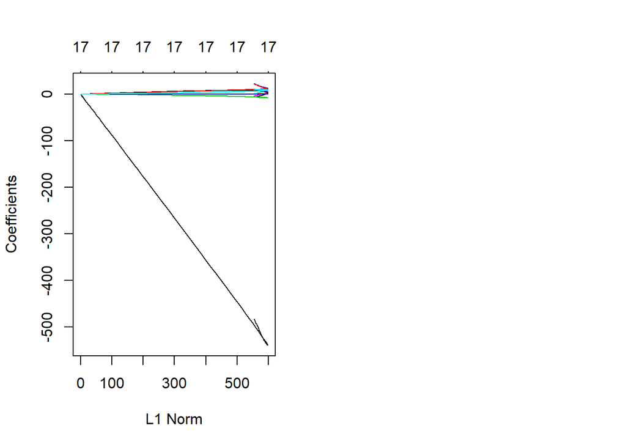

```r
set.seed(99)

apps = train_data_coll$Apps
Ridge.Fit = glmnet(train.matrix.coll[,-2],apps,alpha=0)
par(mfrow=c(1,2))
plot(Ridge.Fit)
CV.R = cv.glmnet(train.matrix.coll[,-2], apps,alpha=0)

LamR = CV.R$lambda.1se # one standard deviation
Lam.minR = CV.R$lambda.min
par(mfrow=c(1,2))
```

[output not shown]

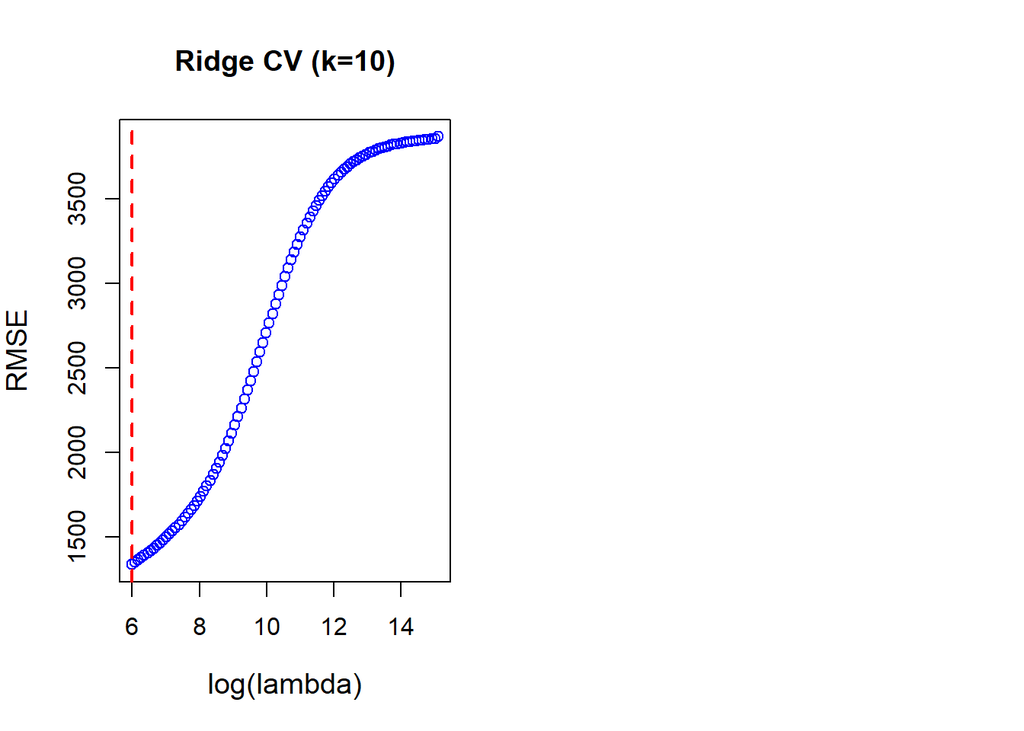

```r
plot(log(CV.R$lambda),sqrt(CV.R$cvm),main="Ridge CV (k=10)",xlab="log(lambda)",ylab = "RMSE",col=4,type="b",cex.lab=1.2)
abline(v=log(Lam.minR),lty=2,col=2,lwd=2)

ridge.pred=predict(Ridge.Fit,s= Lam.minR,newx=test.matrix.coll[,-2])
ridge.rmse = sqrt(mean((ridge.pred-test.matrix.coll[,2])^2))
ridge.rmse
```

#### d.Fit a lasso model on the training set, with lambda chosen by crossvalidation.Report the test error obtained, along with the number of non-zero coefficient estimates.

#### Results from lm,ridge and Lasso are almost same

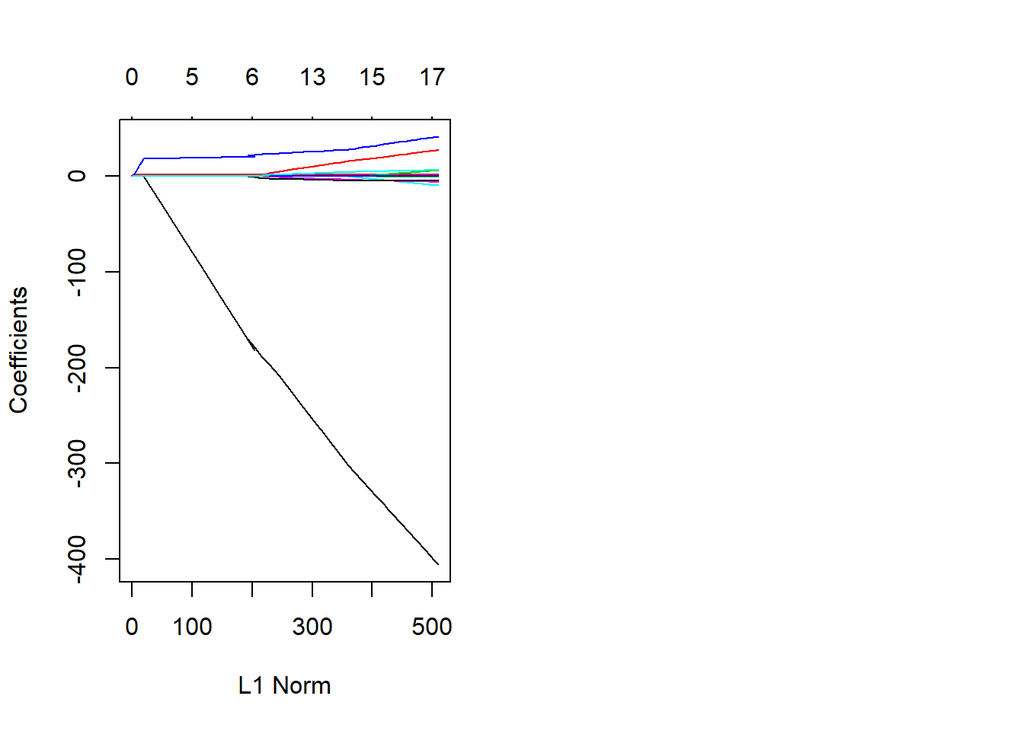

```r
set.seed(99)
lasso.Fit = glmnet(train.matrix.coll[,-2],apps,alpha=1)
par(mfrow=c(1,2))
plot(lasso.Fit)
CV.L = cv.glmnet(train.matrix.coll[,-2], apps,alpha=1)

LamL = CV.L$lambda.1se # one standard deviation
Lam.minL = CV.L$lambda.min
par(mfrow=c(1,2))
```

```r
plot(log(CV.L$lambda),sqrt(CV.L$cvm),main="Lasso CV (k=10)",xlab="log(lambda)",ylab = "RMSE",col=4,type="b",cex.lab=1.2)
abline(v=log(Lam.minL),lty=2,col=2,lwd=2)

Lasso.pred=predict(lasso.Fit,s= Lam.minL,newx=test.matrix.coll[,-2])
Lasso.rmse = sqrt(mean((Lasso.pred-test.matrix.coll[,2])^2))
Lasso.rmse
```

```
## [1] 1157.907
```

```r
coef.L = predict(CV.L,type="coefficients",s=LamL)
coef.L
```

```
## 18 x 1 sparse Matrix of class "dgCMatrix"
##                         1
## (Intercept) -227.54993438
## PrivateYes     .
## Accept         1.30134441
## Enroll         .
## Top10perc     12.51220966
## Top25perc      .
## F.Undergrad    .
## P.Undergrad    .
## Outstate       .
## Room.Board     .
## Books          .
## Personal       .
## PhD            .
## Terminal       .
## S.F.Ratio      .
## perc.alumni    .
## Expend         0.02506643
## Grad.Rate      .
```

[figure not shown]

#### e. PCR method

```r
require(pls)
```

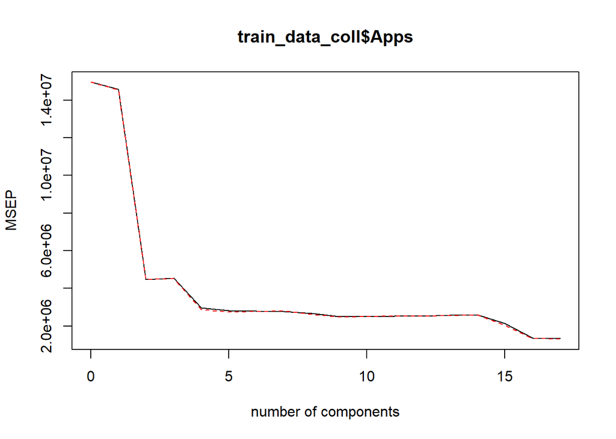

```r
library(pls)
set.seed(1)
pcr.fit=pcr(train_data_coll$Apps~.,data=train_data_coll ,scale =TRUE ,validation ="CV")
validationplot(pcr.fit,val.type="MSEP")
```

```r
pcr.pred=predict (pcr.fit ,test_data_coll, ncomp =4)
pcr.rmse = sqrt(mean((pcr.pred -test_data_coll$Apps)^2))
pcr.rmse
```

```
## [1] 1371.396
```

#### f. PLS method

```r
library(pls)
set.seed (1)
pls.fit=plsr(train_data_coll$Apps~., data=train_data_coll, scale=TRUE ,validation ="CV")
summary (pls.fit )
```

```
## Data:    X dimension: 624 17
##  Y dimension: 624 1
## Fit method: kernelpls
## Number of components considered: 17
##
## VALIDATION: RMSEP
## Cross-validated using 10 random segments.
##        (Intercept)  1 comps  2 comps  3 comps  4 comps  5 comps  6 comps
## CV            3867     1935     1690     1503     1405     1258     1186
## adjCV         3867     1930     1689     1497     1381     1233     1174
##        7 comps  8 comps  9 comps  10 comps  11 comps  12 comps  13 comps
## CV        1161     1158     1155      1151      1154      1153      1154
## adjCV     1152     1150     1147      1143      1145      1144      1145
##        14 comps  15 comps  16 comps  17 comps
## CV         1153      1152      1152      1152
## adjCV      1144      1144      1144      1144
##
## TRAINING: % variance explained
##                       1 comps  2 comps  3 comps  4 comps  5 comps  6 comps
## X                       25.73    44.40    62.88    65.03    67.59    72.99
## train_data_coll$Apps    76.46    83.25    87.13    91.21    92.94    93.07
##                       7 comps  8 comps  9 comps  10 comps  11 comps
## X                       76.78    81.03    82.47     84.69     86.53
## train_data_coll$Apps    93.12    93.14    93.17     93.18     93.19
##                       12 comps  13 comps  14 comps  15 comps  16 comps
## X                        88.35     92.32     94.05     95.51     98.75
## train_data_coll$Apps     93.20     93.20     93.20     93.20     93.20
##                       17 comps
## X                        100.0
## train_data_coll$Apps      93.2
```

```r
pls.pred=predict (pls.fit ,test_data_coll, ncomp =7)
pls.rmse = sqrt(mean((pls.pred -test_data_coll$Apps)^2))
pls.rmse
```

```
## [1] 1221.067
```

#### g. Lasso has the least RMSE among the 5 approaches

### Chapter 6 Problem 11

#### We will now try to predict per capita crime rate in the Boston data set.

#### a.Try out some of the regression methods explored in this chapter, such as best subset selection, the lasso, ridge regression, and PCR. Present and discuss results for the approaches that you consider.

#### Results:

```r
# a.
###################################
## Best subset selection regression
###################################
set.seed(99)
library(caret)
train <- createDataPartition(y=boston_treated$crim,p=0.8,list=FALSE)
train_data_boston <- boston_treated[train,]
train_boston.matrix <- model.matrix(crim~., data=data.frame(train_data_boston))[,-1]
test_data_boston <- boston_treated[-train,]
test_boston.matrix <- model.matrix(crim~., data=data.frame(test_data_boston))[,-1]

library(leaps)
regfit = regsubsets(crim~.,train_data_boston,nvmax = 15)
reg.summary = summary(regfit)
reg.summary$rsq
```

```
##  [1] 0.3649512 0.3919593 0.4007288 0.4080187 0.4142885 0.4216564 0.4251759
##  [8] 0.4274575 0.4287339 0.4295110 0.4300913 0.4306923 0.4306977
```

```r
### Selecting the best subset model by plotting the important characteristics
par(mfrow = c(1,2))
plot(reg.summary$rss,xlab = "Number of variables",ylab = "RSS",type = "l")
plot(reg.summary$adjr2 ,xlab =" Number of Variables ",
ylab=" Adjusted RSq",type="l")

which.max(reg.summary$adjr2)
```

```
## [1] 8
```

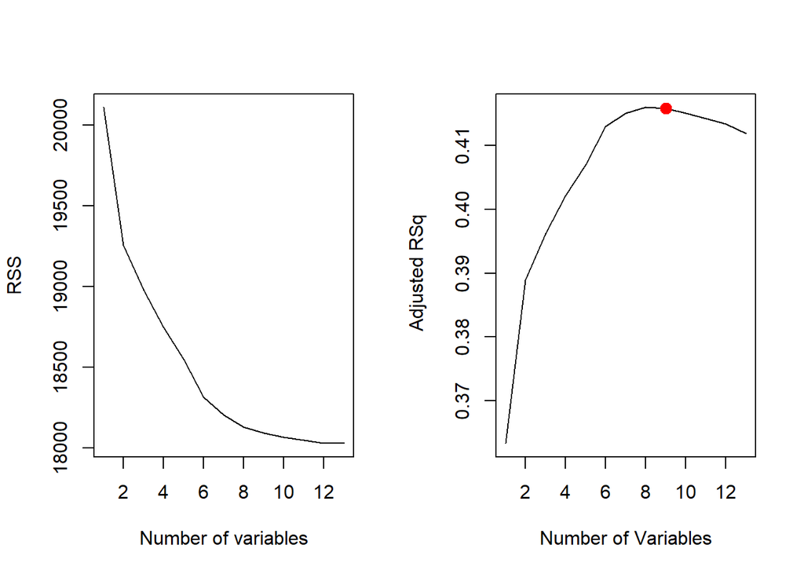

```r
points (9, reg.summary$adjr2[9], col ="red",cex =2, pch =20)
```

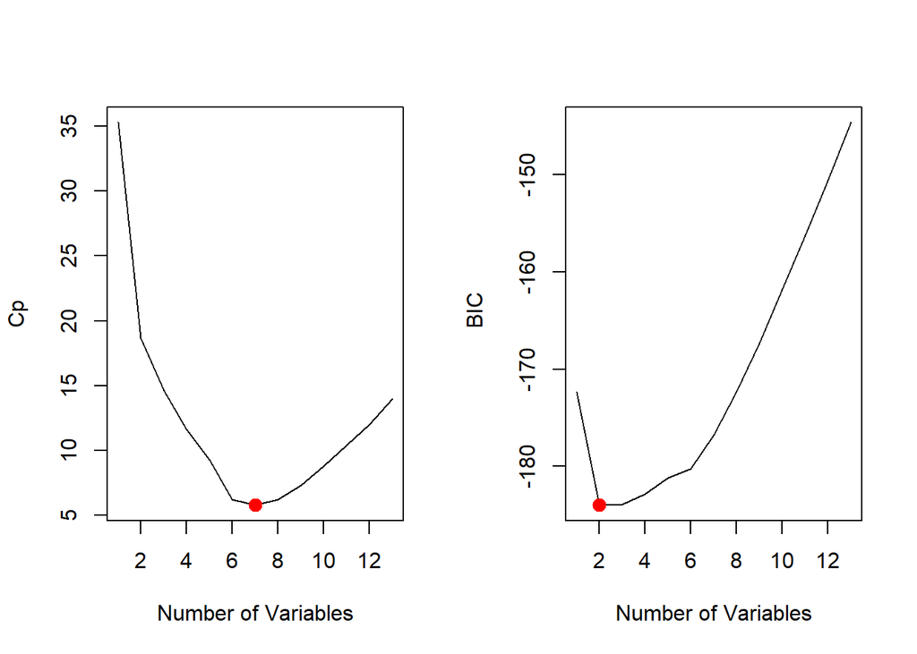

```r
plot(reg.summary$cp ,xlab =" Number of Variables ",ylab="Cp",type="l")
cp.min = which.min (reg.summary$cp)
points (cp.min, reg.summary$cp [cp.min], col ="red",cex =2, pch =20)

bic.min = which.min (reg.summary$bic)
plot(reg.summary$bic ,xlab=" Number of Variables ",ylab=" BIC",type = "l")
points (bic.min, reg.summary$bic [bic.min], col =" red",cex =2, pch =20)
```

```r
##################
# Ridge regression
##################


library(glmnet)
set.seed(99)
head(train_boston.matrix)
```

```
##   zn indus chas   nox    rm  age    dis rad tax ptratio  black lstat medv
## 1 18  2.31    0 0.538 6.575 65.2 4.0900   1 296    15.3 396.90  4.98 24.0
## 2  0  7.07    0 0.469 6.421 78.9 4.9671   2 242    17.8 396.90  9.14 21.6
## 3  0  7.07    0 0.469 7.185 61.1 4.9671   2 242    17.8 392.83  4.03 34.7
## 4  0  2.18    0 0.458 6.998 45.8 6.0622   3 222    18.7 394.63  2.94 33.4
## 5  0  2.18    0 0.458 7.147 54.2 6.0622   3 222    18.7 396.90  5.33 36.2
## 6  0  2.18    0 0.458 6.430 58.7 6.0622   3 222    18.7 394.12  5.21 28.7
```

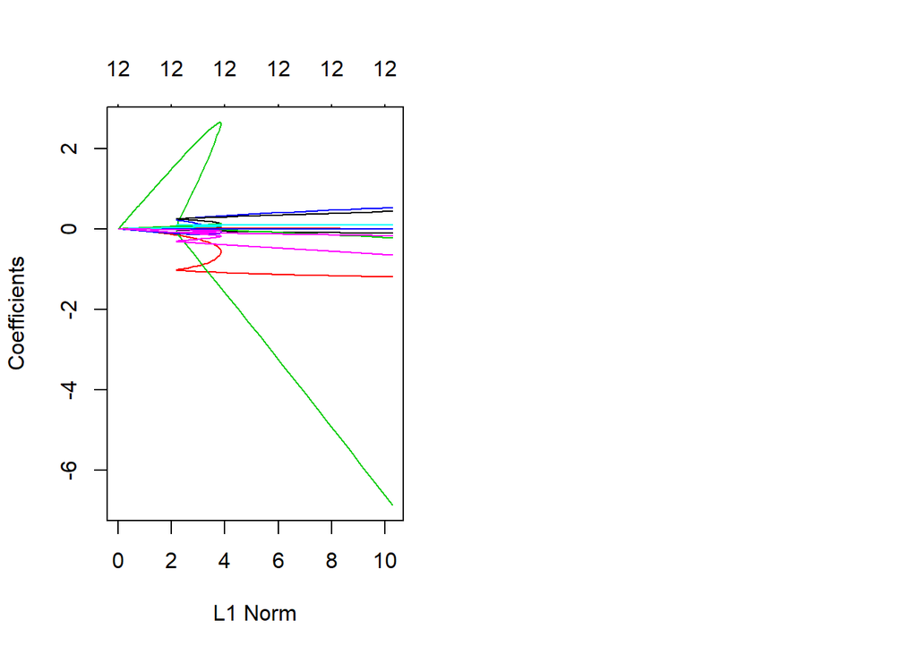

```r
crim = train_data_boston$crim
Ridge.Fit = glmnet(train_boston.matrix[,-1],crim,alpha=0)
par(mfrow=c(1,2))
plot(Ridge.Fit)
CV.R = cv.glmnet(train_boston.matrix[,-1], crim,alpha=0)

LamR = CV.R$lambda.1se # one standard deviation
Lam.minR = CV.R$lambda.min
par(mfrow=c(1,2))
```

```r
plot(log(CV.R$lambda),sqrt(CV.R$cvm),main="Ridge CV (k=10)",xlab="log(lambda)",ylab = "RMSE",col=4,type="b",cex.lab=1.2)
abline(v=log(Lam.minR),lty=2,col=2,lwd=2)
head(test_data_boston)
```

```
##       crim   zn indus chas   nox    rm   age    dis rad tax ptratio  black
## 10 0.17004 12.5  7.87    0 0.524 6.004  85.9 6.5921   5 311    15.2 386.71
## 11 0.22489 12.5  7.87    0 0.524 6.377  94.3 6.3467   5 311    15.2 392.52
## 19 0.80271  0.0  8.14    0 0.538 5.456  36.6 3.7965   4 307    21.0 288.99
## 20 0.72580  0.0  8.14    0 0.538 5.727  69.5 3.7965   4 307    21.0 390.95
## 24 0.98843  0.0  8.14    0 0.538 5.813 100.0 4.0952   4 307    21.0 394.54
## 27 0.67191  0.0  8.14    0 0.538 5.813  90.3 4.6820   4 307    21.0 376.88
##    lstat medv
## 10 17.10 18.9
## 11 20.45 15.0
## 19 11.69 20.2
## 20 11.28 18.2
## 24 19.88 14.5
## 27 14.81 16.6
```

```r
ridge.pred=predict(Ridge.Fit,s= Lam.minR,newx=test_boston.matrix[,-2])
ridge.rmse = sqrt(mean((ridge.pred-test_data_boston[,1])^2))
ridge.rmse
```

```
## [1] 6.179467
```

[figure not shown]

```r
#Lasso Regression
set.seed(99)
crim = train_data_boston$crim
Lasso.Fit = glmnet(train_boston.matrix[,-1],crim,alpha=1)
par(mfrow=c(1,2))
```

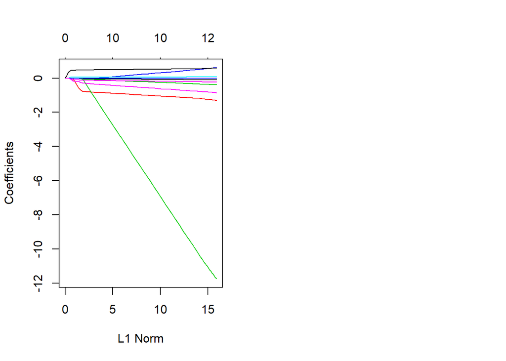

```r
plot(Lasso.Fit)
CV.L = cv.glmnet(train_boston.matrix[,-1], crim,alpha=1)

LamL = CV.L$lambda.1se # one standard deviation
Lam.minL = CV.L$lambda.min
par(mfrow=c(1,2))
```

```r
plot(log(CV.L$lambda),sqrt(CV.L$cvm),main="Lasso CV (k=10)",xlab="log(lambda)",ylab = "RMSE",col=4,type="b",cex.lab=1.2)
abline(v=log(Lam.minL),lty=2,col=2,lwd=2)

lasso.pred=predict(Lasso.Fit,s= Lam.minL,newx=test_boston.matrix[,-2])
lasso.rmse = sqrt(mean((lasso.pred-test_data_boston[,1])^2))
lasso.rmse
```

```
## [1] 5.88871
```

```r
coef.R = predict(CV.R,type="coefficients",s=Lam.minR)
coef.R
```

```
## 13 x 1 sparse Matrix of class "dgCMatrix"
##                        1
## (Intercept) 11.845538777
## indus       -0.102157857
## chas        -1.188373223
## nox         -6.531485661
## rm           0.517625868
## age         -0.001288490
## dis         -0.636451332
## rad          0.428232158
## tax          0.004048461
## ptratio     -0.204546535
## black       -0.010186180
## lstat        0.100999520
## medv        -0.167954611
```

[figure not shown]

### Chapter 4 Problem 10

#### This question should be answered using the Weekly data set, which is part of the ISLR package. This data is similar in nature to the Smarket data from this chapters lab, except that it contains 1, 089 weekly returns for 21 years, from the beginning of 1990 to the end of 2010.

- Logistic regression provided the best results among the two

```r
# a to d sub parts

library(ISLR)
names(Weekly)
```

```
## [1] "Year"      "Lag1"      "Lag2"      "Lag3"      "Lag4"      "Lag5"
## [7] "Volume"    "Today"     "Direction"
```

```r
dim(Weekly)
```

```
## [1] 1089    9
```

```r
summary(Weekly)
```

```
##       Year           Lag1               Lag2               Lag3
##  Min.   :1990   Min.   :-18.1950   Min.   :-18.1950   Min.   :-18.1950
##  1st Qu.:1995   1st Qu.: -1.1540   1st Qu.: -1.1540   1st Qu.: -1.1580
##  Median :2000   Median :  0.2410   Median :  0.2410   Median :  0.2410
##  Mean   :2000   Mean   :  0.1506   Mean   :  0.1511   Mean   :  0.1472
##  3rd Qu.:2005   3rd Qu.:  1.4050   3rd Qu.:  1.4090   3rd Qu.:  1.4090
##  Max.   :2010   Max.   : 12.0260   Max.   : 12.0260   Max.   : 12.0260
##       Lag4               Lag5              Volume
##  Min.   :-18.1950   Min.   :-18.1950   Min.   :0.08747
##  1st Qu.: -1.1580   1st Qu.: -1.1660   1st Qu.:0.33202
##  Median :  0.2380   Median :  0.2340   Median :1.00268
##  Mean   :  0.1458   Mean   :  0.1399   Mean   :1.57462
##  3rd Qu.:  1.4090   3rd Qu.:  1.4050   3rd Qu.:2.05373
##  Max.   : 12.0260   Max.   : 12.0260   Max.   :9.32821
##      Today          Direction
##  Min.   :-18.1950   Down:484
##  1st Qu.: -1.1540   Up  :605
##  Median :  0.2410
##  Mean   :  0.1499
##  3rd Qu.:  1.4050
##  Max.   : 12.0260
```

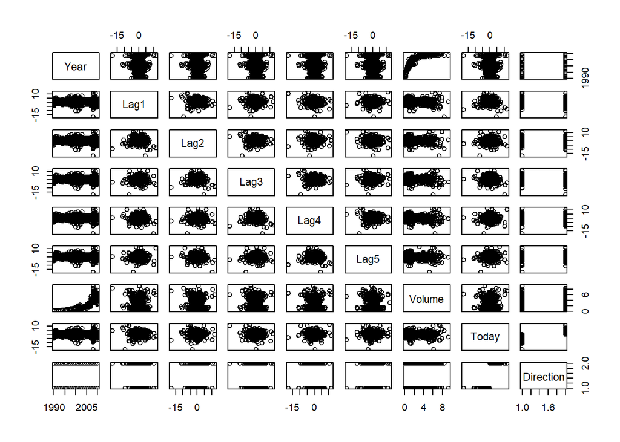

```r
pairs(Weekly)
```

```r
# There appears to be a relationship between year and volume and none other than that

cor(Weekly [,-9])
```

```
##               Year         Lag1        Lag2        Lag3         Lag4
## Year    1.00000000 -0.032289274 -0.03339001 -0.03000649 -0.031127923
## Lag1   -0.03228927  1.000000000 -0.07485305  0.05863568 -0.071273876
## Lag2   -0.03339001 -0.074853051  1.00000000 -0.07572091  0.058381535
## Lag3   -0.03000649  0.058635682 -0.07572091  1.00000000 -0.075395865
## Lag4   -0.03112792 -0.071273876  0.05838153 -0.07539587  1.000000000
## Lag5   -0.03051910 -0.008183096 -0.07249948  0.06065717 -0.075675027
## Volume  0.84194162 -0.064951313 -0.08551314 -0.06928771 -0.061074617
## Today  -0.03245989 -0.075031842  0.05916672 -0.07124364 -0.007825873
##                Lag5      Volume        Today
## Year   -0.030519101  0.84194162 -0.032459894
## Lag1   -0.008183096 -0.06495131 -0.075031842
## Lag2   -0.072499482 -0.08551314  0.059166717
## Lag3    0.060657175 -0.06928771 -0.071243639
## Lag4   -0.075675027 -0.06107462 -0.007825873
## Lag5    1.000000000 -0.05851741  0.011012698
## Volume -0.058517414  1.00000000 -0.033077783
## Today   0.011012698 -0.03307778  1.000000000
```

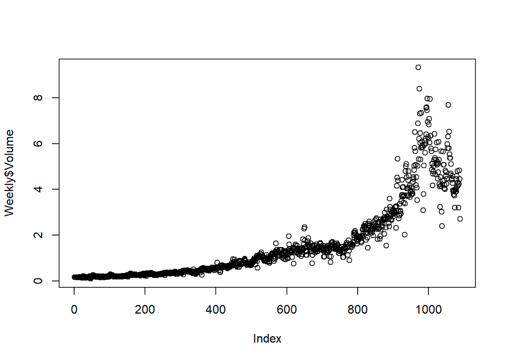

```r
plot(Weekly$Volume)
```

```r
######################
## Logistic Regression
######################


glm.fit=glm(Direction~Lag1+Lag2+Lag3+Lag4+Lag5+Volume ,
              data=Weekly ,family =binomial )
summary (glm.fit)
```

```
##
## Call:
## glm(formula = Direction ~ Lag1 + Lag2 + Lag3 + Lag4 + Lag5 +
##     Volume, family = binomial, data = Weekly)
##
## Deviance Residuals:
##     Min       1Q   Median       3Q      Max
## -1.6949  -1.2565   0.9913   1.0849   1.4579
##
## Coefficients:
##             Estimate Std. Error z value Pr(>|z|)
## (Intercept)  0.26686    0.08593   3.106   0.0019 **
## Lag1        -0.04127    0.02641  -1.563   0.1181
## Lag2         0.05844    0.02686   2.175   0.0296 *
## Lag3        -0.01606    0.02666  -0.602   0.5469
## Lag4        -0.02779    0.02646  -1.050   0.2937
## Lag5        -0.01447    0.02638  -0.549   0.5833
## Volume      -0.02274    0.03690  -0.616   0.5377
## ---
## Signif. codes:  0 '***' 0.001 '**' 0.01 '*' 0.05 '.' 0.1 ' ' 1
##
## (Dispersion parameter for binomial family taken to be 1)
##
##     Null deviance: 1496.2  on 1088  degrees of freedom
## Residual deviance: 1486.4  on 1082  degrees of freedom
## AIC: 1500.4
##
## Number of Fisher Scoring iterations: 4
```

```r
# Lag 2 appears to be statistically significant
# confusion matrix

fitted.results <- predict(glm.fit,type='response')

# Confusion matrix
cm_logistic <- table(Weekly$Direction, fitted.results>= 0.5)
cm_logistic
```

```
##
##        FALSE TRUE
##   Down    54  430
##   Up      48  557
```

```r
# 0.56 accuracy
# The model has a lot of false positives

# Fitting the logistic regression model
# Splitting the data for 1990 to 2008


train_data = subset(Weekly, Year >= 1990 & Year <=2008, select = c('Direction','Lag2'))
test_data = subset(Weekly, Year >= 2009, select = c('Direction','Lag2'))

glm.fit.train = glm(Direction~Lag2,data=train_data,family =binomial )
summary (glm.fit.train)
```

```
##
## Call:
## glm(formula = Direction ~ Lag2, family = binomial, data = train_data)
##
## Deviance Residuals:
##    Min      1Q  Median      3Q     Max
## -1.536  -1.264   1.021   1.091   1.368
##
## Coefficients:
##             Estimate Std. Error z value Pr(>|z|)
## (Intercept)  0.20326    0.06428   3.162  0.00157 **
## Lag2         0.05810    0.02870   2.024  0.04298 *
## ---
## Signif. codes:  0 '***' 0.001 '**' 0.01 '*' 0.05 '.' 0.1 ' ' 1
##
## (Dispersion parameter for binomial family taken to be 1)
##
##     Null deviance: 1354.7  on 984  degrees of freedom
## Residual deviance: 1350.5  on 983  degrees of freedom
## AIC: 1354.5
##
## Number of Fisher Scoring iterations: 4
```

```r
fitted.results.test <- predict(glm.fit.train,test_data[2],type='response')
# Confusion matrix
cm_logistic.test <- table(test_data$Direction, fitted.results.test>= 0.5)
cm_logistic.test
```

```
##
##        FALSE TRUE
##   Down     9   34
##   Up       5   56
```

```r
#Accuracy : 0.625

#################
# KNN with K = 1
#################
## KNN and the last question are yet to be answered
## Better to normalize in case of varied scales of data
library(class)
library(kknn)
set.seed(99)
near = kknn(Direction~.,train_data,test_data,k=1,kernel = "rectangular")

table(near$fitted,test_data$Direction)
```

```
##
##        Down Up
##   Down   22 31
##   Up     21 30
```

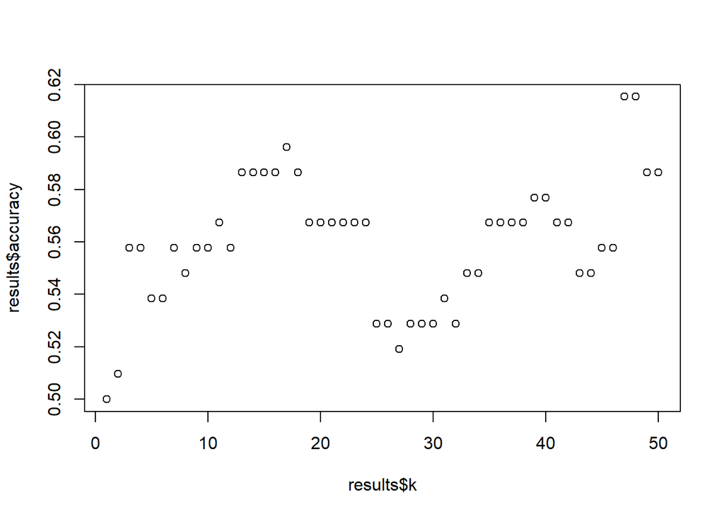

```r
# 50% is the accuracy

#using different values of k in the knn classifier
results = data.frame(k=1:50,accuracy=NA)
k = 1:50
accuracy = list()
for(i in k){
  near = kknn(Direction~.,train_data,test_data,k=i,kernel = "rectangular")
  accuracy = mean(test_data$Direction == near$fitted)
  results$accuracy[i] = accuracy
}
plot(results$k,results$accuracy)
```

```r
## increase in k does not necessarily increase accuracy in this case
```

### Chapter 8 : Problem 8

In the lab, a classification tree was applied to the Carseats data set after converting Sales into a qualitative response variable. Now we will seek to predict Sales using regression trees and related approaches,treating the response as a quantitative variable.(a) Split the data set into a training set and a test set. (b) Fit a regression tree to the training set. Plot the tree, and interpret the results. What test error rate do you obtain? (c) Use cross-validation in order to determine the optimal level of tree complexity. Does pruning the tree improve the test error rate? (d) Use the bagging approach in order to analyze this data. What test error rate do you obtain? Use the importance() function to determine which variables are most important (e) Use random forests to analyze this data. What test error rate do you obtain? Use the importance() function to determine which variables are most important. Describe the effect of m, the number of variables considered at each split, on the error rate obtained.

```r
library(tree)
library(ISLR)
carseats_copy = Carseats
# Split training and test data
library(caret)
set.seed(99)
train <- createDataPartition(y=carseats_copy$Sales,p=0.8,list=FALSE)
train_data_car <- carseats_copy[train,]
train_carseats.matrix <- model.matrix(~., data=data.frame(train_data_car))[,-1]
test_data_car <- carseats_copy[-train,]
test_car.matrix <- model.matrix(~., data=data.frame(test_data_car))[,-1]

library(tree)
tree.carseats =tree(carseats_copy$Sales~.,carseats_copy )
summary(tree.carseats)
```

```
##
## Regression tree:
## tree(formula = carseats_copy$Sales ~ ., data = carseats_copy)
## Variables actually used in tree construction:
## [1] "ShelveLoc"   "Price"       "Age"         "Income"      "Population"
## [6] "Advertising"
## Number of terminal nodes:  17
## Residual mean deviance:  2.878 = 1102 / 383
## Distribution of residuals:
##     Min.  1st Qu.   Median     Mean  3rd Qu.     Max.
## -4.98700 -1.23000 -0.06125  0.00000  1.22500  4.75400
```

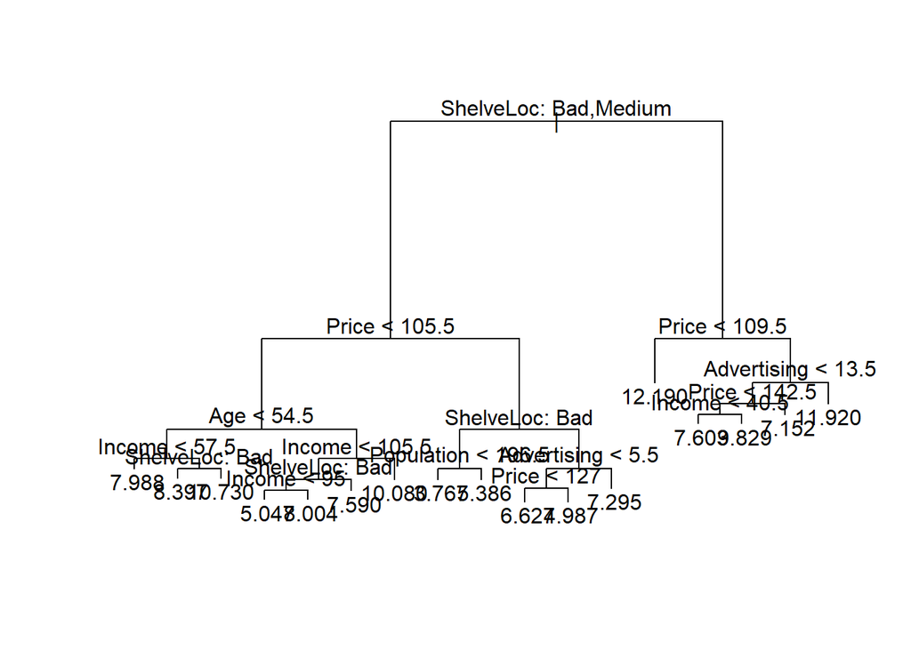

```r
plot(tree.carseats)
text(tree.carseats ,pretty =0)
```

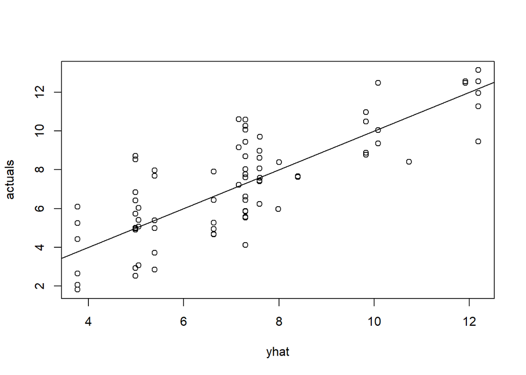

```r
yhat=predict(tree.carseats ,newdata = test_data_car)
actuals = test_data_car$Sales
plot(yhat ,actuals)
abline (0,1)
```

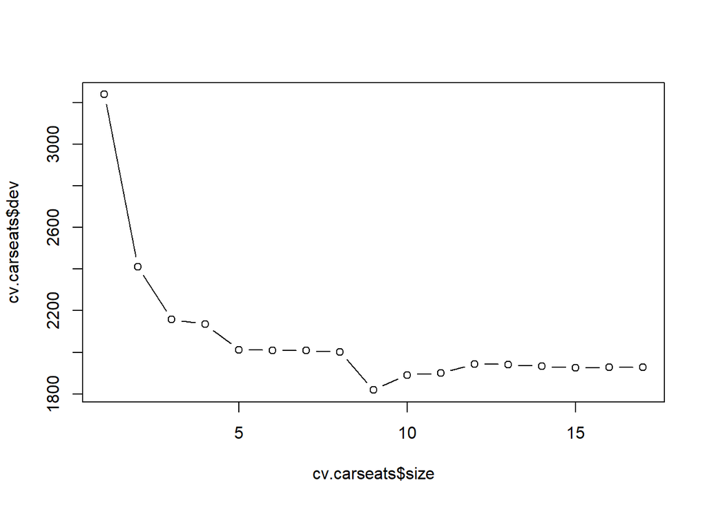

```r
rmse.tree = sqrt(mean((yhat - actuals)^2))
# 1.67

## Using cross- validation to decide the optimum level of pruning the tree
cv.carseats =cv.tree(tree.carseats)
plot(cv.carseats$size ,cv.carseats$dev ,type='b')
```